# CineVision - Análisis Exploratorio

Flavio Galán, José Prince

2025-01-31

## Resumen del conjunto de Datos

Los datos tienen la siguiente forma:

```
##        id             budget             genres            homePage
##  Min.   :     5   Min.   :        0   Length:10000       Length:10000
##  1st Qu.: 12286   1st Qu.:        0   Class :character   Class :character
##  Median :152558   Median :   500000   Mode  :character   Mode  :character
##  Mean   :249877   Mean   : 18551632
##  3rd Qu.:452022   3rd Qu.: 20000000
##  Max.   :922260   Max.   :380000000
##  productionCompany  productionCompanyCountry productionCountry
##  Length:10000       Length:10000             Length:10000
##  Class :character   Class :character         Class :character
##  Mode  :character   Mode  :character         Mode  :character
##
##
##
##     revenue             runtime        video           director
##  Min.   :0.000e+00   Min.   :  0.0   Mode :logical   Length:10000
##  1st Qu.:0.000e+00   1st Qu.: 90.0   FALSE:9430      Class :character
##  Median :1.631e+05   Median :100.0   TRUE :84        Mode  :character
##  Mean   :5.674e+07   Mean   :100.3   NA's :486
##  3rd Qu.:4.480e+07   3rd Qu.:113.0
##  Max.   :2.847e+09   Max.   :750.0
##     actors          actorsPopularity   actorsCharacter    originalTitle
##  Length:10000       Length:10000       Length:10000       Length:10000
##  Class :character   Class :character   Class :character   Class :character
##  Mode  :character   Mode  :character   Mode  :character   Mode  :character
##
##
##
##     title           originalLanguage     popularity        releaseDate
##  Length:10000       Length:10000       Min.   :    4.258   Length:10000
##  Class :character   Class :character   1st Qu.:   14.578   Class :character
##  Mode  :character   Mode  :character   Median :   21.906   Mode  :character
##                                        Mean   :   51.394
##                                        3rd Qu.:   40.654
##                                        Max.   :11474.647
##     voteAvg         voteCount      genresAmount    productionCoAmount
##  Min.   : 1.300   Min.   :    1   Min.   : 0.000   Min.   : 0.000
##  1st Qu.: 5.900   1st Qu.:  120   1st Qu.: 2.000   1st Qu.: 2.000
##  Median : 6.500   Median :  415   Median : 3.000   Median : 3.000
##  Mean   : 6.483   Mean   : 1342   Mean   : 2.596   Mean   : 3.171
##  3rd Qu.: 7.200   3rd Qu.: 1316   3rd Qu.: 3.000   3rd Qu.: 4.000
##  Max.   :10.000   Max.   :30788   Max.   :16.000   Max.   :89.000
##  productionCountriesAmount  actorsAmount    castWomenAmount
##  Min.   :  0.000           Min.   :     0   Length:10000
##  1st Qu.:  1.000           1st Qu.:    13   Class :character
##  Median :  1.000           Median :    21   Mode  :character
##  Mean   :  1.751           Mean   :  2148
##  3rd Qu.:  2.000           3rd Qu.:    36
##  Max.   :155.000           Max.   :919590
##  castMenAmount
##  Length:10000
##  Class :character
##  Mode  :character
##
##
##
```

## Preguntas

### ¿Cuáles son las 10 películas que contaron con más presupuesto?

```
##                                           Título Presupuesto
## 717  Pirates of the Caribbean: On Stranger Tides   380000000
## 4711                     Avengers: Age of Ultron   365000000
## 5953                           Avengers: Endgame   356000000
## 164     Pirates of the Caribbean: At World's End   300000000
## 4954                              Justice League   300000000
## 5954                      Avengers: Infinity War   300000000
## 608                             Superman Returns   270000000
## 3792                                     Tangled   260000000
## 7135                               The Lion King   260000000
## 281                                 Spider-Man 3   258000000
```

Como se puede ver la película con mayor presupuesto es: Pirates of the Caribbean: On Stranger Tides con un presupuesto de: 380000000 dólares! Mientras que la última película dentro del top 10 es: Spider-Man 3 con un presupuesto de $258000000.

### ¿Cuáles son las 10 películas que más ingresos tuvieron?

```
##                            Título   Ingresos
## 3211                       Avatar 2847246203
## 5953            Avengers: Endgame 2797800564
## 308                       Titanic 2187463944
## 4948 Star Wars: The Force Awakens 2068223624
## 5954       Avengers: Infinity War 2046239637
## 4915               Jurassic World 1671713208
## 7135                The Lion King 1667635327
## 9050      Spider-Man: No Way Home 1631853496
## 3398                 The Avengers 1518815515
## 5088                    Furious 7 1515047671
```

Como se puede ver la película con mayores ingresos es: Avatar con una cantidad de: 2.8472462^{9} dólares! Mientras que la última película dentro del top 10 es: Furious 7 con un ingresos de $1.5150477^{9}.

### ¿Cuál es la película que más votos tuvo?

La película que más votos tuvo es: Inception con una cantidad de votos igual a: 30788.

### ¿Cuál es la peor película de acuerdo a los votos de todos los usuarios?

La película que menos votos tuvo es: La Mera Reyna del Sur con una cantidad de votos igual a: 1.

### ¿Cuántas películas se hicieron en cada año? ¿En qué año se hicieron más películas? Haga un gráfico de barras

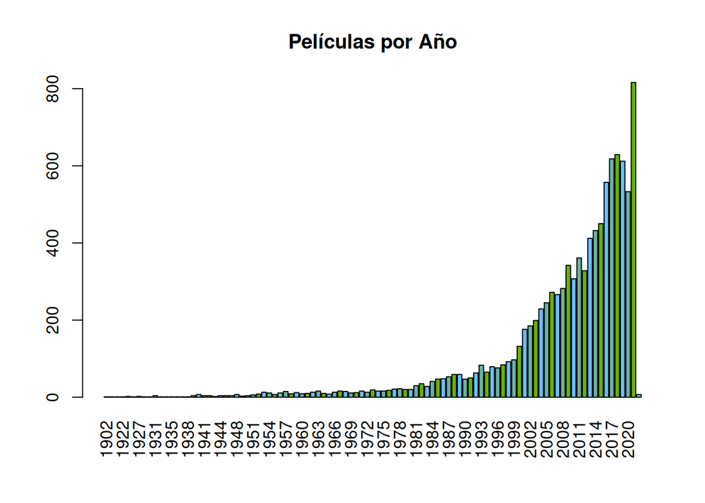

La tendencia en general de las películas ha ido en aumento conforme pasan los años, los demás datos de 2000 hacia atrás son más y más bajos.

En el año en donde más películas se han hecho es en el 2021 con un total de: 816 películas que fueron lanzadas al cine.

### ¿Cuál es el género principal de las 20 películas más recientes? ¿Cuál es el género principal que predomina en el conjunto de datos? Represéntelo usando un gráfico.

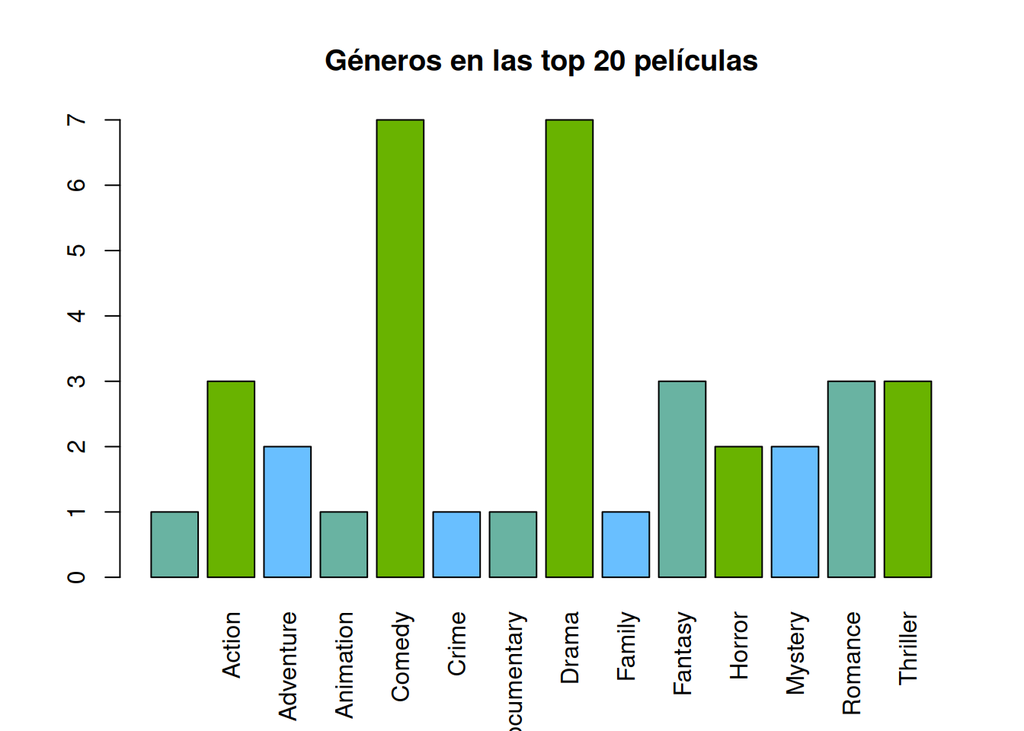

Los dos géneros más populares entre las últimas 20 películas son Comedia y Drama. Mientras que en todos los datos:

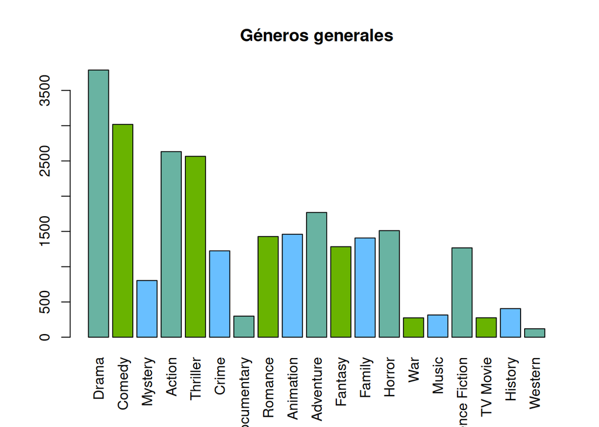

El género principal que predomina en todos los datos es Drama con una cantidad de películas del género igual a 3789.

**¿A qué género principal pertenecen las películas más largas?**

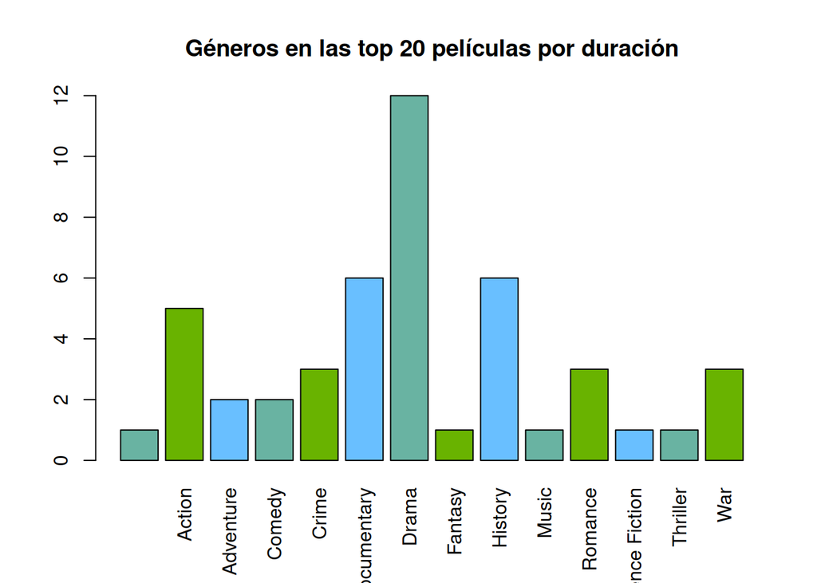

En la gráfica de arriba podemos ver los géneros de las top 20 películas más largas, como se puede ver el género de drama es el más usado y por una gran ventaja.

### ¿Las películas de qué genero principal obtuvieron mayores ganancias?

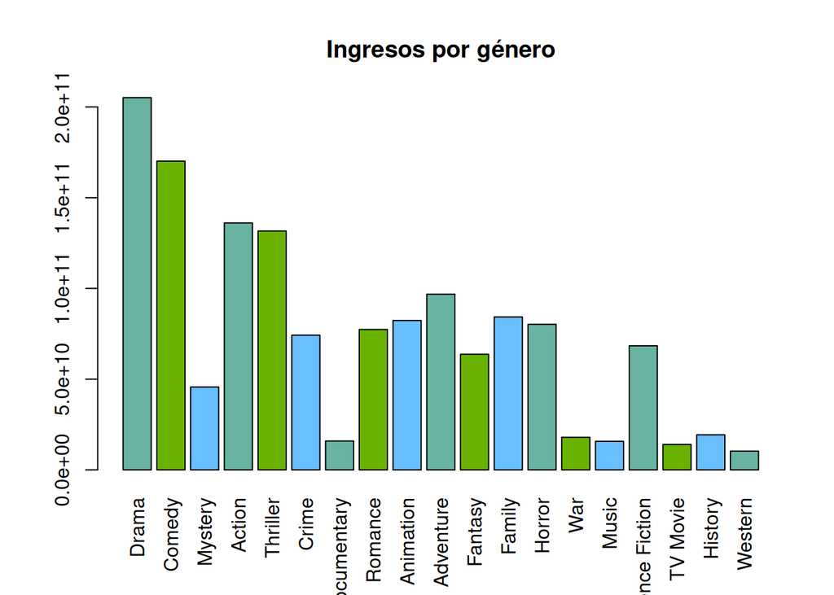

Como se puede ver en la gráfica, el género de película que mayores ingresos genera es Drama seguido de Comedia con $2.0515967^{11}y $1.7012558^{11} respectivamente.

### ¿La cantidad de actores influye en los ingresos de las películas? ¿Se han hecho películas con más actores en los últimos años?

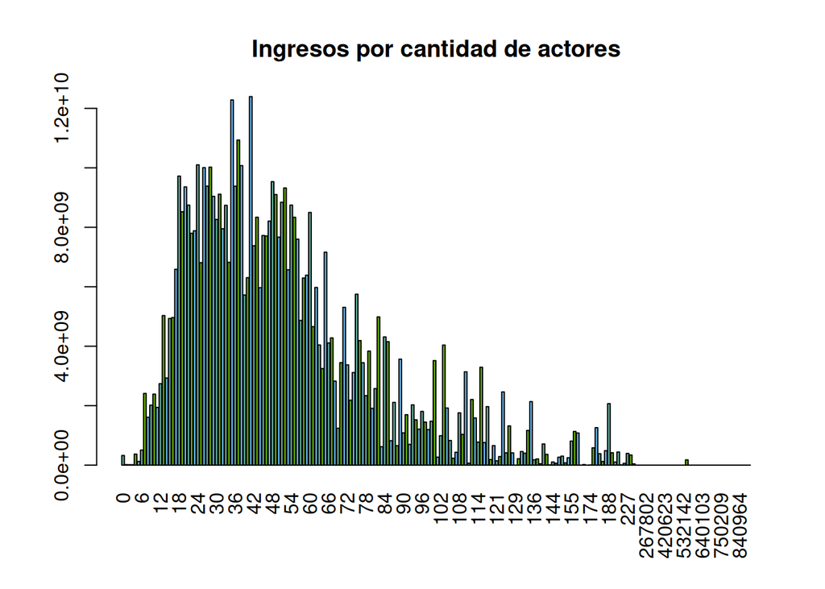

Como se puede ver, una mayor cantidad de actores no implica una mayor cantidad de ingresos sin embargo se tiene un buen punto medio alrededor de 42 actores.

Con respecto a la cantidad de actores por años podemos reflejarlo en el siguiente gráfico:

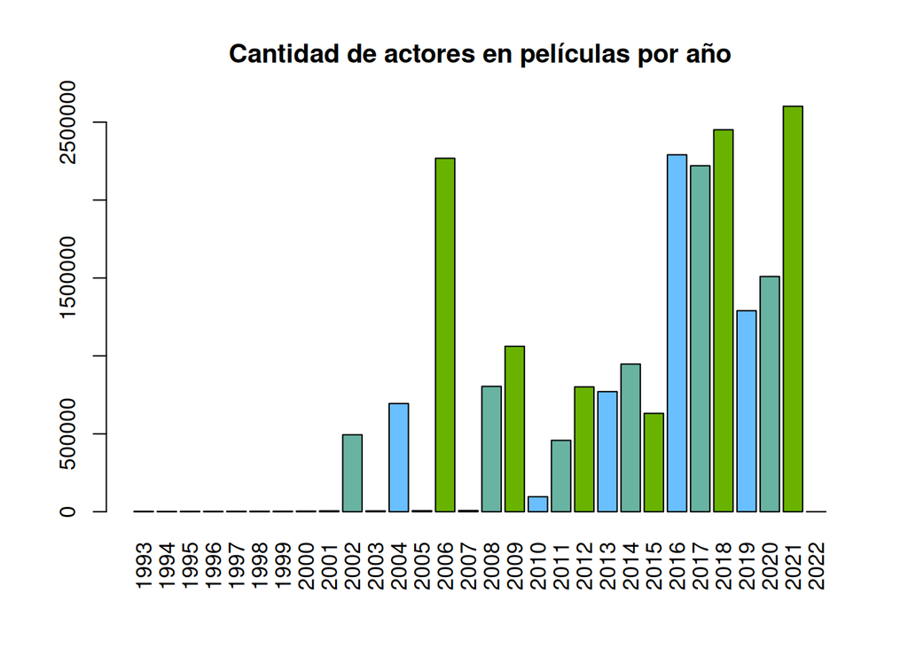

### ¿Es posible que la cantidad de hombres y mujeres en el reparto influya en la popularidad y los ingresos de las películas?

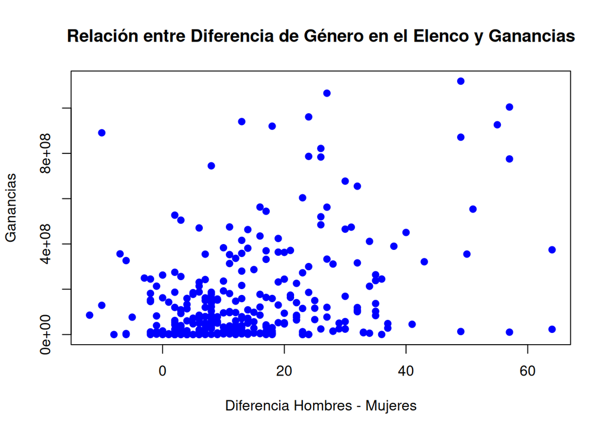

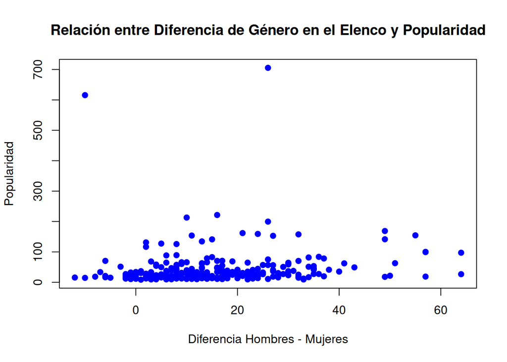

### ¿Quiénes son los directores que hicieron las 20 películas mejor calificadas?

```
##                                                                 director
##                                                                   <char>
##  1:                                                      Robert Zemeckis
##  2:                                                 Francis Ford Coppola
##  3:                                                         George Lucas
##  4:                                                           Fritz Lang
##  5:                                                        Michel Gondry
##  6:                                                           Sam Mendes
##  7:                                                         Orson Welles
##  8:                                                    Quentin Tarantino
##  9:                                                       Lars von Trier
## 10:                                                       Clint Eastwood
## 11:                                                       Andrew Stanton
## 12:                                                       Gore Verbinski
## 13:                                 Alejandro Gonz\xe1lez I\xf1\xe1rritu
## 14:                                                           Luc Besson
## 15:                                                       Gore Verbinski
## 16:                                                      David Silverman
## 17:                                                           Sam Mendes
## 18:                                                      Stephen Hopkins
## 19: Allison Anders|Alexandre Rockwell|Robert Rodriguez|Quentin Tarantino
## 20:                                                 Michael Winterbottom
##                                                                 director
```

### ¿Cómo se correlacionan los presupuestos con los ingresos? ¿Los altos presupuestos significan altos ingresos? Haga los gráficos que necesite, histograma, diagrama de dispersión

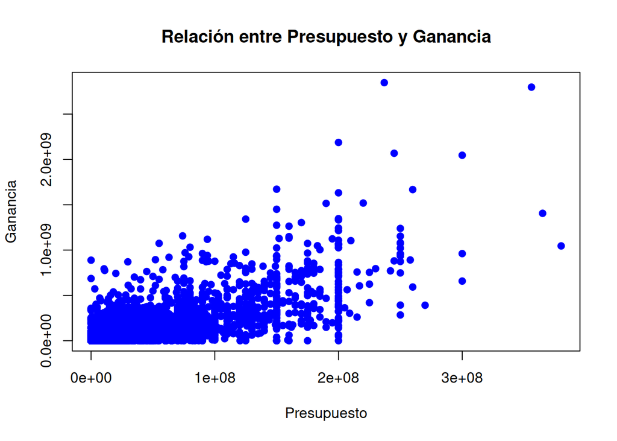

Se puede encontrar una relación entre el presupuesto y la ganancia. Es apreciable como a mayor presupuesto hay una mayor ganancia en las peliculas. Para corroborar este dato podemos calcular la variable de correlación que es 0.757454, al ser cercanan a 1 nos inidica una correlación positiva entre el presupuesto y las ganancias.

### ¿Se asocian ciertos meses de lanzamiento con mejores ingresos?

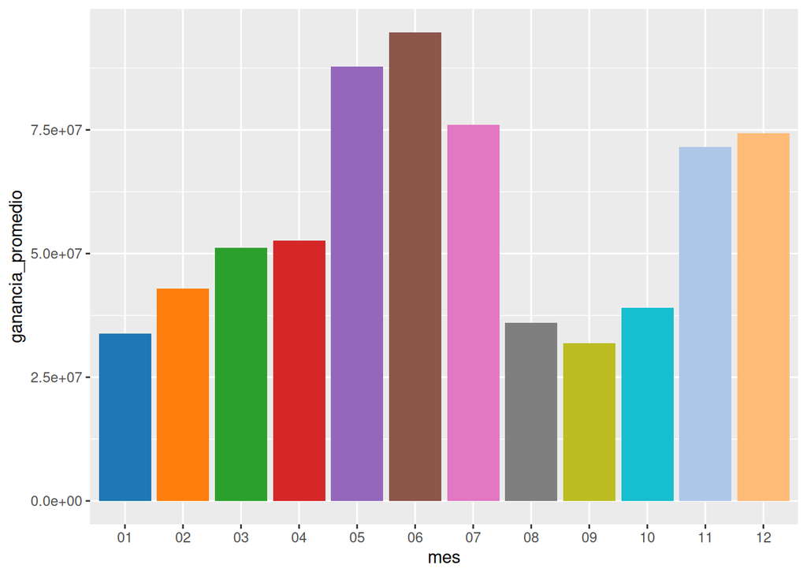

Se puede ver que los mejores meses para generar ingresos es en Junio y Mayo.

### ¿En qué meses se han visto los lanzamientos con mejores ingresos?¿cuantas películas, en promedio, se han lanzado por mes?

Los meses donde se han visto los mejores lanzamientos han sido: April, June, July, November, December.

A continuación se muestra el promedio de peliculas por mes:

```
## # A tibble: 12 × 2
##    mes   promedio_peliculas
##    <chr>              <dbl>
##  1 01                  6.59
##  2 02                  7.13
##  3 03                  8.23
##  4 04                  7.03
##  5 05                  7.05
##  6 06                  8.27
##  7 07                  8.20
##  8 08                  9.22
##  9 09                 10.9
## 10 10                 10.8
## 11 11                  8.15
## 12 12                  9.44
```

### ¿Cómo se correlacionan las calificaciones con el éxito comercial?

```
## [1] 0.1644844
```

Según el coeficiente de correlación entre las calificaciones y el éxito comercial de una pelicula, nos indica que no existe una clara relación entre estas variables y que pueden haber peliculas que no sean exitosos comerciales pero tengan buena calificación como exitos comerciales que tengan mala calificación, entre otros posibles casos.

### ¿Qué estrategias de marketing, como videos promocionales o páginas oficiales, generan mejores resultados?

```
##                  Categoria Promedio_Ganancia
## 1 Sin homePage y con video          423701.5
## 2 Con homePage y sin video        77757141.6
## 3 Con homePage y con video          712829.1
```

Se ve que la mejor estrategia de marketing son las páginas oficiles sin ofrecer video.

### ¿La popularidad del elenco está directamente correlacionada con el éxito de taquilla?

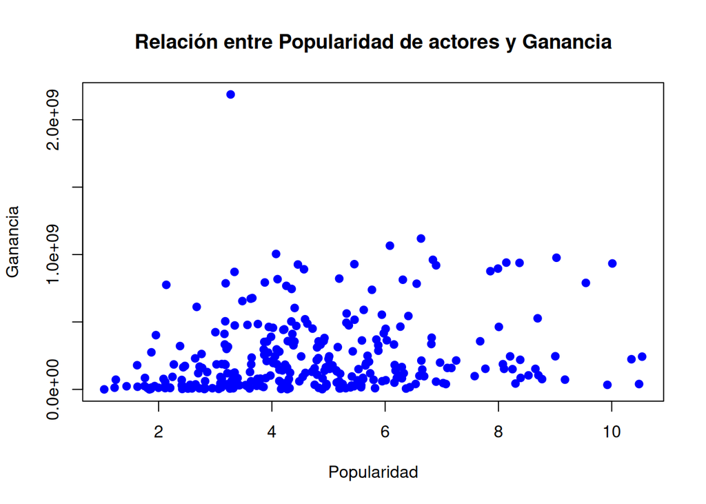

Se puede ver que no existe una correlación clara entre la popularidad de los actores de una cinta con su ganacia, esto es incluso más perceptible con el coeficiente de correlación que es cercano a 0: 0.2184582.

## Preguntas Extras

### ¿Las películas más largas generan mayores ingresos o reciben mejores calificaciones?

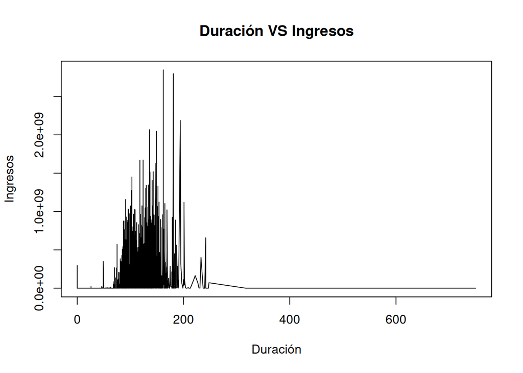

Como se puede ver, las películas más largas no necesariamente implican una mayor cantidad de ingresos, de hecho varias de las películas que han generado grandes cantidades de ingresos son menores en duración a 200 minutos. Ahora con respecto al rating:

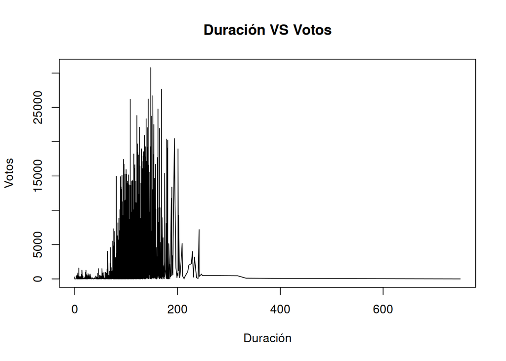

Como se puede ver por la gráfica, una mayor duración de la película no implica una mayor cantidad de votos.

### ¿Qué países producen más películas?

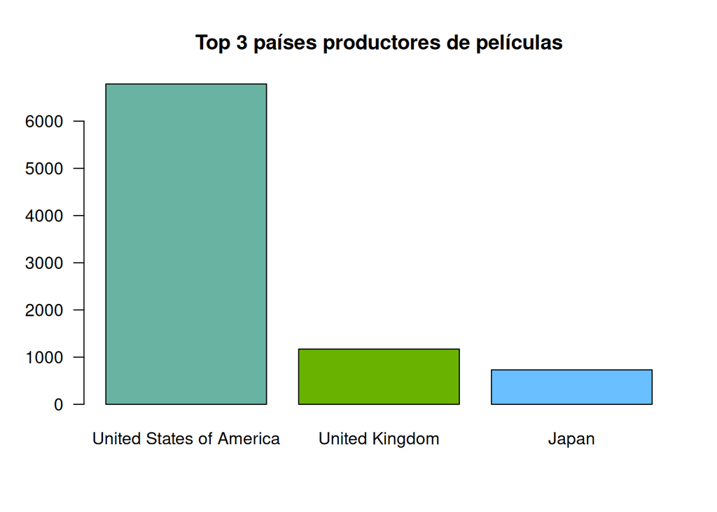

Como se puede ver, el país que produce la mayor cantidad de películas es los Estados Unidos de América y por mucho, ya que en total ha producido 6788 películas.

### ¿Las películas con más géneros combinados tienen mejores ingresos?

[figure not shown]

### ¿Cómo ha evolucionado el presupuesto el presupuesto promedio de las peliculas a lo largo de los años?

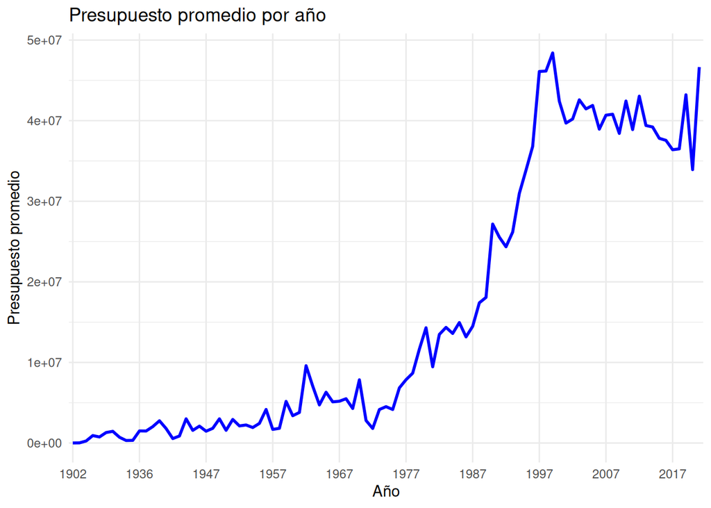

Se puede ver un aumento en el presupuesto a lo largo de los años, lleagndo a su punto más alto a finales de los años 90. El presupuesto promedio tuvo un leve descenso en este siglo XXI pero ya en años más recientes el presupuesto promedio por año ha estado en ascenso.

### ¿En qué años se han producido las películas con los mayores presupuestos?

```
##        Año Presupuesto                                    Pelicula
##     <char>       <int>                                      <char>
##  1:   2011   380000000 Pirates of the Caribbean: On Stranger Tides
##  2:   2015   365000000                     Avengers: Age of Ultron
##  3:   2019   356000000                           Avengers: Endgame
##  4:   2007   300000000    Pirates of the Caribbean: At World's End
##  5:   2017   300000000                              Justice League
##  6:   2018   300000000                      Avengers: Infinity War
##  7:   2006   270000000                            Superman Returns
##  8:   2010   260000000                                     Tangled
##  9:   2019   260000000                               The Lion King
## 10:   2007   258000000                                Spider-Man 3
```

Estos serían los años en donde se han producido las peliculas con mayores presupuesto, adjunto a esta información se encuentra el nombre respectivo de la pelicula.

### ¿Cuáles son las compañías productoras más exitosas en términos de ingresos generados?

```
## # A tibble: 10 × 2
##    `Compañia productora`    ingresos
##    <chr>                       <dbl>
##  1 Warner Bros. Pictures 73125430577
##  2 Universal Pictures    59998142684
##  3 20th Century Fox      53616322587
##  4 Walt Disney Pictures  50473884686
##  5 Columbia Pictures     49391994178
##  6 Paramount             46821942038
##  7 Marvel Studios        26749513210
##  8 New Line Cinema       23949924024
##  9 DreamWorks Pictures   18873769309
## 10 Legendary Pictures    17504220931
```

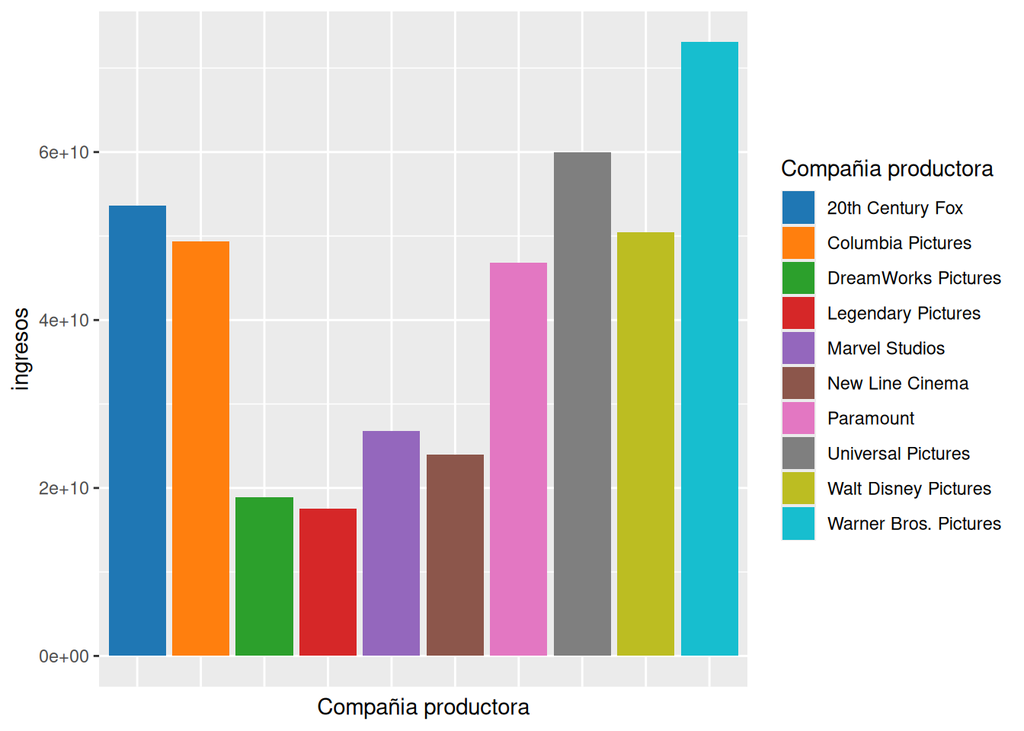

Estas son las Compañias productoras más exitosas en terminos de los ingresos totales generados. Es apreciable estudios como “Warner Bros. Pictures” tenga el mayor número de ingresos debido a que es uno de las compañias más longevas y que sigue vigente a día de hoy.